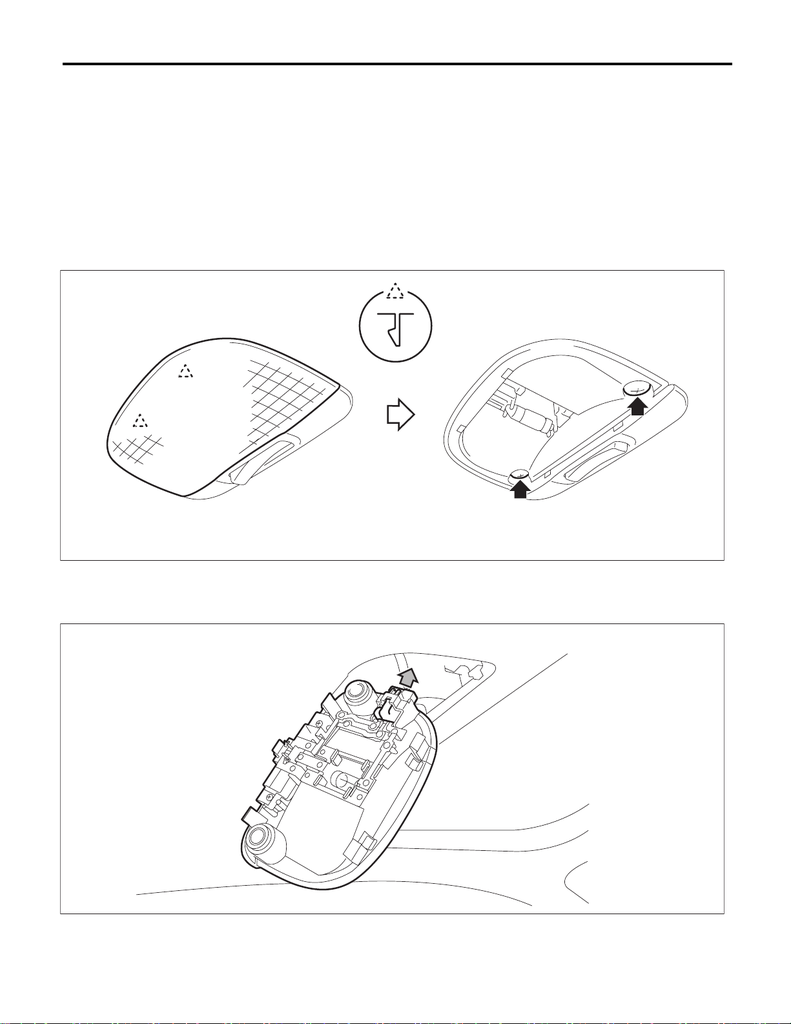

LI-62

Room Light

LIGHTING SYSTEM

33.Room Light

A: REMOVAL

1) Disconnect the ground cable from battery. <Ref. to NT-5, BATTERY, NOTE, Note.>

NOTE:

For models other than STI model, disconnect the ground terminal from battery sensor.

2) Remove the light assembly - room.

CAUTION:

When using a flat tip screwdriver, apply protective tape or cloth and be careful not to cause damage.

(1) Release the claws and remove the lens.

(2) Remove the screws.

(3) Disconnect the connector and remove the light assembly - room and the room light bulb.

CAUTION:

Use a dry clean cloth so that no grease or water adheres to the glass portion of the bulb.

LI-01041

LI-01042

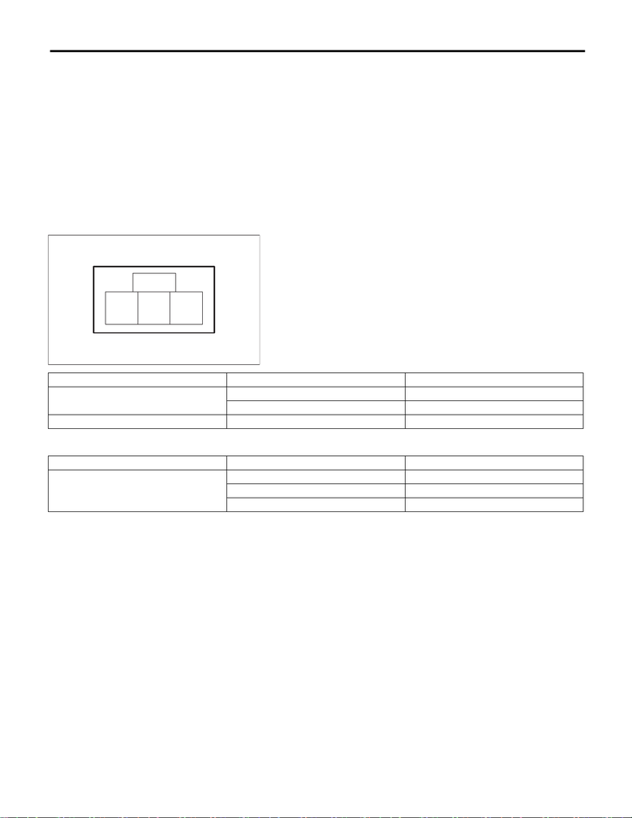

LI-63

Room Light

LIGHTING SYSTEM

B: INSTALLATION

1) Install the room light bulb and light assembly - room.

CAUTION:

Use a dry clean cloth so that no grease or water adheres to the glass portion of the bulb.

2) Connect the battery ground terminal. <Ref. to NT-5, BATTERY, NOTE, Note.>

NOTE:

For models other than STI model, connect the ground terminal to battery sensor.

C: INSPECTION

1) Measure the resistance between connector terminals.

Preparation tool:

Circuit tester

2) Apply battery voltage between the connector terminals to check the lighting condition of the light.

3) Replace the light assembly - room if the inspection result is not within the standard value.

LI-01809

3 1

2

Terminal No. Inspection conditions Standard

1 — 3

Switch OFF 1 MΩ or more

Switch ON Less than 1 Ω

2 — 3 Switch door Less than 1 Ω

Terminal No. Inspection conditions Specification

3 (+) — 1 (–)

3 (+) — 2 (–)

Switch OFF Light OFF

Switch ON Light ON

Switch door Light ON